# Exploring Symptom Patterns and Diagnostic Classification

A Computational Analysis of Synthetic Mental Health Data

PIPS Group: Tess, Sherilyn, Misia | Programming in Psychological Science

2026-10-22

### 0.0.1 Project at a glance

| Dataset | Diagnostic categories | Core methods |
| --- | --- | --- |
| **3,753 synthetic profiles** | **5 psychiatric categories** | Chi-square tests, FDR correction, rule-based classification and Shiny simulation |

This report examines statistical patterns in synthetic psychiatric symptom data and demonstrates how predefined classification rules respond to different symptom combinations.

# 1 Introduction

This project examines the relationship between psychiatric symptoms and diagnostic classifications using a synthetic mental health dataset. The dataset contains binary indicators representing symptoms and diagnostic criteria associated with five psychiatric disorders: bipolar disorder, schizophrenia, depression, anxiety disorders, and post-traumatic stress disorder (PTSD).

The primary aim is to explore how symptom patterns relate to diagnostic outcomes and to demonstrate how statistical and computational methods can be used to investigate these relationships. Specifically, the project addresses three questions: (1) How strongly are individual symptoms associated with their corresponding diagnoses and with other psychiatric diagnoses? (2) To what extent do different diagnoses co-occur in the dataset? (3) How do symptom counts and diagnostic thresholds influence the likelihood of meeting the dataset’s diagnostic classification rules?

To address these questions, the project combines data preparation and validation, rule-based diagnostic classification, statistical association tests, graphical visualisations, and an interactive Shiny application. The application enables users to explore synthetic symptom profiles, modify individual symptom indicators, and observe how these changes affect diagnostic classifications under the dataset’s predefined rules.

Importantly, the dataset is synthetically generated, and its diagnostic indicators follow predefined rules. Consequently, the analyses primarily demonstrate computational and statistical relationships within the simulated data rather than providing empirical evidence about symptom distributions, diagnostic validity, or comorbidity in clinical populations.

# 2 Dataset

The dataset was obtained from Kaggle (Bakshi, n.d.). The dataset (Mentalillness.csv, Kaggle) contains 3,753 synthetic participants with 53 binary DSM-5 symptoms and criteria (0 = absent, 1 = present) and 5 binary diagnoses: bipolar disorder, schizophrenia, depression, anxiety disorder, and PTSD. It is stored in the `data` folder. The dataset was obtained from Kaggle (Bakshi, n.d.) and contains binary indicators representing psychiatric symptoms, diagnostic criteria, and diagnostic classifications. Although these variables are organised around DSM-5 diagnostic categories (American Psychiatric Association, 2013), the dataset implements simplified classification rules rather than reproducing the complete clinical diagnostic framework. Consequently, the observations should be treated as synthetic cases for demonstrating data analysis and computational classification, rather than as clinical patient records.

Because the original column names are long, we first build a variable key that gives each column a short name and records which disorder and DSM-5 criterion it belongs to. The key is saved as `data/variable_key.csv`. We then load the data with these short names and check that every value is 0 or 1.

```r
source("src/r/functions_data.R")
source("src/r/functions_variable_key.R")

variable_key <- make_variable_key()
save_variable_key(variable_key, "data/variable_key.csv")
```

```
## Variable key saved to data/variable_key.csv
```

```r
clindata <- load_mental_illness("data/Mentalillness.csv", variable_key)
```

```
## Check passed: all 58 columns contain only 0 and 1.
```

```r
knitr::kable(head(variable_key, 10))
```

| original | name | disorder | criterion |
| --- | --- | --- | --- |
| Inflated self-esteem | bip_inflated_self_esteem | bipolar | symptom |
| Distractibility | bip_distractibility | bipolar | symptom |
| Increase in goal-directed activity | bip_goal_directed_activity | bipolar | symptom |
| Excessive involvement in activities with high potential for painful consequences | bip_risky_activities | bipolar | symptom |
| Racing thoughts | bip_racing_thoughts | bipolar | symptom |
| Decreased need for sleep | bip_decreased_sleep_need | bipolar | symptom |
| More talkative than usual | bip_talkative | bipolar | symptom |
| Disorganized thinking or speech | scz_disorganized_speech | schizophrenia | positive |
| Intrusive memories or flashbacks | scz_intrusive_memories | schizophrenia | other |
| Diminished emotional expression | scz_diminished_expression | schizophrenia | other |

## 2.1 DSM rules

The diagnoses in the dataset follow fixed counting rules. The script `test_dsm_rules.R` rebuilds all five diagnoses from the symptom columns (with `apply_dsm_rules()`) and checks them in two ways.

First, it checks that the rebuilt diagnoses match the diagnoses in the data for every participant.

```r
knitr::kable(rule_check)
```

| disorder | n_observed | n_rebuilt | n_match | percent_match |
| --- | --- | --- | --- | --- |
| bipolar | 2909 | 2909 | 3753 | 100 |
| depression | 1845 | 1845 | 3753 | 100 |
| anxiety | 1622 | 1622 | 3753 | 100 |
| schizophrenia | 3167 | 3167 | 3753 | 100 |
| ptsd | 203 | 203 | 3753 | 100 |

### 2.1.1 Tests

Second, it tests the rules on made-up participants placed exactly at a cutoff (or just below it), whose diagnosis we know in advance. This is where mistakes like `>` instead of `>=` would show up.

```r
knitr::kable(test_results)
```

| test | passed |
| --- | --- |
| Bipolar: 3 symptoms = yes, 2 = no | TRUE |
| Depression: 5 symptoms = yes, 4 = no | TRUE |
| Anxiety: needs 2 symptoms AND duration | TRUE |
| Schizophrenia: positive symptom needed, 2 items in total | TRUE |
| PTSD: all minimums = yes, missing G or 1 D item = no | TRUE |
| Thresholds: bipolar cutoff 2 diagnoses someone with 2 symptoms | TRUE |

# 3 Dataset overview

Overview of the mental health dataset

[output not shown]

The dataset contains 3,753 synthetic participant records. Individual symptoms and diagnostic criteria are represented using binary variables, with 0 indicating absence and 1 indicating presence. Diagnostic indicators identify whether each participant meets the corresponding classification rules.

The original variable names are mapped to shorter, standardised names using a variable key. This facilitates reproducible data processing and statistical analysis while preserving the correspondence between variables and their original descriptions.

Because the dataset was generated synthetically, its distributions and diagnostic relationships should not be interpreted as representative of clinical populations.

# 4 Interactive component

The project includes an interactive Shiny application implemented in `Shiny_Sim.Rmd`, designed to demonstrate how individual symptom profiles contribute to rule-based psychiatric classifications. Users can select from 3,753 synthetic example profiles and inspect the corresponding symptoms and diagnostic classifications across five psychiatric categories: bipolar disorder, depression, anxiety, schizophrenia, and posttraumatic stress disorder (PTSD).

The application presents symptoms organised by disorder and diagnostic criterion, using descriptive labels and interactive checkboxes to distinguish present and absent indicators. Users can modify individual symptom values to simulate alternative profiles. Following each modification, the application recalculates diagnostic classifications using the existing `apply_dsm_rules()` function and its predefined thresholds. The displayed classifications update in response to these changes, enabling users to explore how the same classification rules produce different outcomes depending on the symptom combination.

A reset function restores the selected example profile’s original symptom values and corresponding classifications. All modifications remain temporary and do not alter the underlying dataset. Users can also select another example profile to examine different combinations of symptoms.

Additionally, the application includes an expandable DSM-5 reference section that allows users to compare the dataset’s classification logic with clinical diagnostic criteria. Importantly, the implemented rules are simplified and do not fully reproduce DSM-5 diagnostic requirements. The application therefore serves as an educational simulation of computational classification rather than a clinical diagnostic tool.

To launch the application, open `Shiny_Sim.Rmd` in RStudio and execute its code chunks in sequence. Further instructions are provided in the repository’s `README.md`.

# 5 Statistical analysis

The script `analyses.R` runs the tests and `plots.R` makes the figures.

## 5.1 Worked example

To show how each test works, we tested whether depressed mood was significantly associated with a depression diagnosis. A chi-square test of independence compares the observed counts with the counts expected under independence; phi (φ) gives the effect size.

```r
example_table
```

```
##
##        0    1
##   0 1236  686
##   1  672 1159
```

```r
example_test
```

```
##
##  Pearson's Chi-squared test with Yates' continuity correction
##
## data:  example_table
## X-squared = 284.84, df = 1, p-value < 2.2e-16
```

```r
round(example_phi, 3)
```

```
## [1] 0.276
```

Depressed mood was significantly associated with a depression diagnosis, χ²(1) = 284.84, p < .001, φ = .28.

## 5.2 Symptoms and diagnoses

We repeated this test for every symptom against every diagnosis (53 × 5 = 265 tests). P-values were corrected for multiple testing with the Benjamini–Hochberg false discovery rate (FDR, q < .05).

```r
knitr::kable(association_summary)
```

| symptom_vs_diagnosis | n_tests | n_significant | phi_min | phi_max |
| --- | --- | --- | --- | --- |
| same disorder | 53 | 37 | -0.023 | 0.895 |
| other disorder | 212 | 0 | -0.039 | 0.045 |

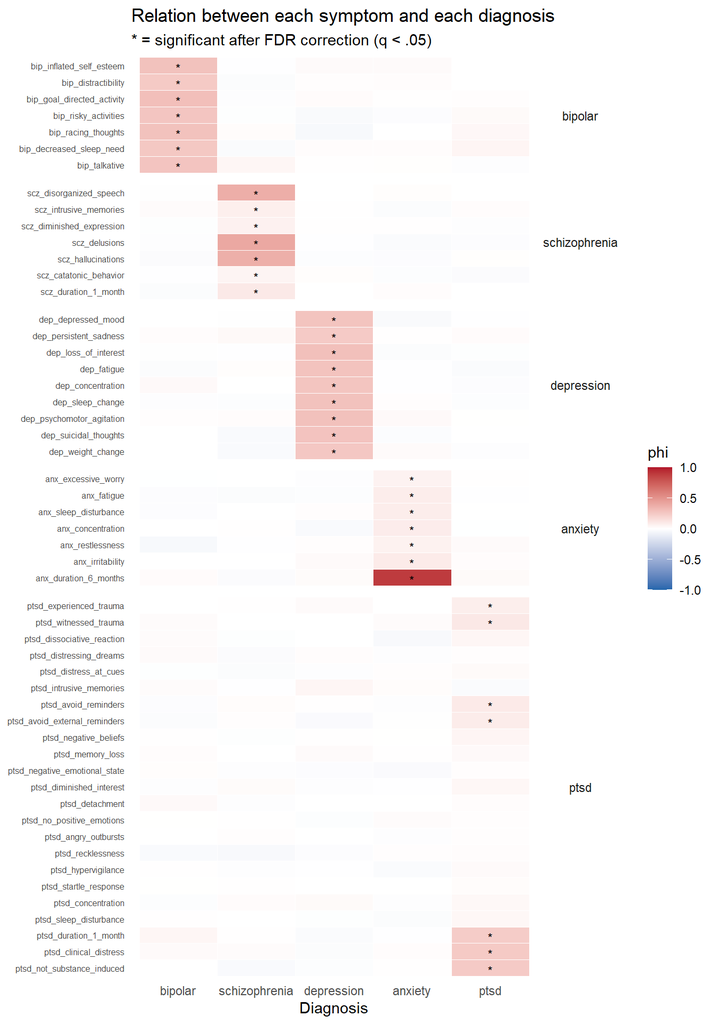

```r
heatmap_plot
```

After FDR correction, 37 of 53 symptoms were significantly associated with their own diagnosis (φ up to .90). None of the 212 symptom–other-diagnosis pairs were significant (φ = -.04 to .05). This patter is consistent with each diagnosis being determined only by its own symptoms. All 16 non-significant within-disorder association involved PTSD symptoms (φ =< .05). Because PTSD requires all eight criteria to be met at once, so a single symptom barely changes the odds of the diagnosis.

## 5.3 Comorbidity

For every pair of diagnoses, we used a chi-square test to compare the observed number of participants with diagnoses against the number of expected under independence. P-values were FDR-corrected across the 10 pairs.

```r
knitr::kable(comorbidity, digits = 3)
```

| disorder_1 | disorder_2 | observed | expected | ratio | chi_square | p | p_fdr |
| --- | --- | --- | --- | --- | --- | --- | --- |
| bipolar | schizophrenia | 2446 | 2454.8 | 1.00 | 0.80 | 0.372 | 0.532 |
| bipolar | depression | 1427 | 1430.1 | 1.00 | 0.04 | 0.840 | 0.840 |
| bipolar | anxiety | 1273 | 1257.2 | 1.01 | 1.45 | 0.228 | 0.457 |
| bipolar | ptsd | 166 | 157.3 | 1.05 | 1.99 | 0.159 | 0.457 |
| schizophrenia | depression | 1543 | 1556.9 | 0.99 | 1.46 | 0.227 | 0.457 |
| schizophrenia | anxiety | 1358 | 1368.7 | 0.99 | 0.86 | 0.353 | 0.532 |
| schizophrenia | ptsd | 175 | 171.3 | 1.02 | 0.40 | 0.525 | 0.609 |
| depression | anxiety | 807 | 797.4 | 1.01 | 0.36 | 0.548 | 0.609 |
| depression | ptsd | 86 | 99.8 | 0.86 | 3.68 | 0.055 | 0.315 |
| anxiety | ptsd | 101 | 87.7 | 1.15 | 3.46 | 0.063 | 0.315 |

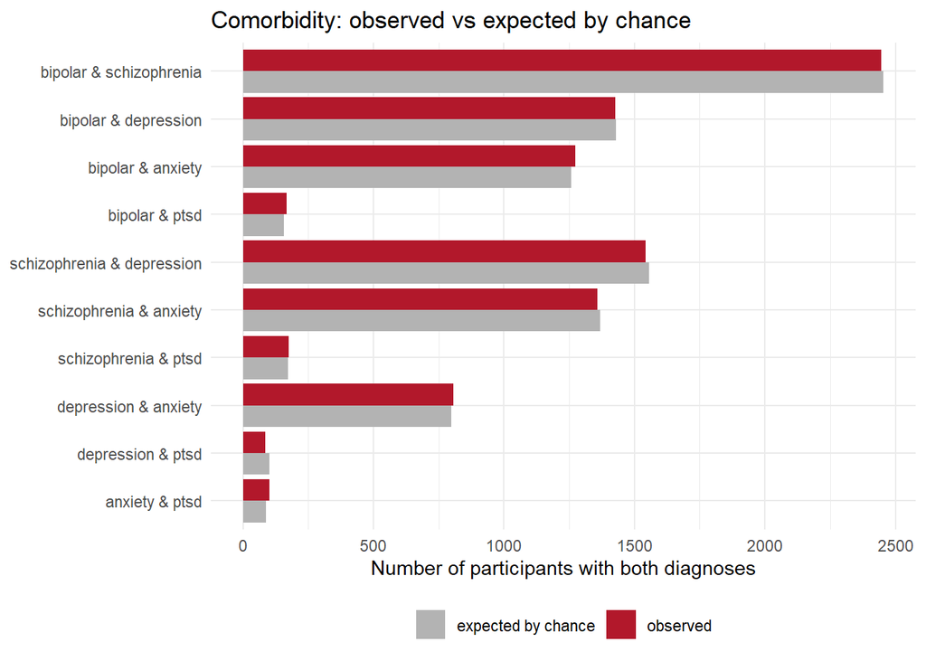

```r
comorbidity_plot
```

Observed co-occurrence did not differ significantly from the expected value for any of the ten pairs (observed/expected ratios .86-1.15, all FDR-corrected p > .31). This contrasts with clinical data, where diagnoses typically co-occur more often than expected by chance.

## 5.4 Symptom count and diagnosis

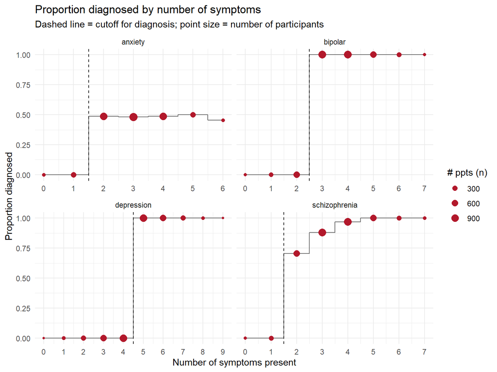

```r
steps_plot
```

For bipolar and depression, the proportion diagnosed jumps from 0 to 1 exactly at the cutoff. For anxiety it levels off at about .50, because the diagnosis also requires the 6-month duration item, which about half of participants have. For schizophrenia it rises gradually, because a positive symptom is also required. The dip at 6 anxiety symptoms (.46) most likely reflects sampling variation in a small group (n = 66).

# 6 Discussion

The present project investigated symptom–diagnosis associations, diagnostic comorbidity, and symptom-count thresholds using a synthetic mental health dataset. By combining statistical analyses, rule-based classification, and visualisations, the project demonstrated how computational methods can be used to explore relationships between psychiatric symptoms and diagnostic outcomes. However, the findings must be interpreted within the context of the dataset’s predefined classification rules rather than as empirical evidence concerning psychiatric disorders.

## 6.1 Symptom–diagnosis associations

Following false discovery rate (FDR) correction, 37 of the 53 symptom variables showed statistically significant associations with their corresponding diagnoses, whereas none of the 212 cross-disorder comparisons reached statistical significance. These findings are consistent with the dataset’s structure, in which each diagnostic indicator is determined by its associated symptom variables. Consequently, the within-disorder associations are partly inherent to the classification process rather than independently discovered relationships.

The absence of statistically significant cross-disorder associations may similarly reflect how the synthetic dataset was generated. In clinical populations, psychiatric disorders frequently share symptoms, risk factors, and underlying mechanisms (Caspi & Moffitt, 2018). Therefore, the present findings should not be interpreted as evidence that psychiatric symptoms are disorder-specific or that transdiagnostic processes are absent.

Notably, the 16 within-disorder comparisons that did not reach statistical significance involved PTSD-related variables. This finding illustrates how the relationship between an individual symptom and an overall diagnostic classification depends on the structure of the classification rule. PTSD requires the simultaneous satisfaction of several criteria, meaning that the presence of an individual symptom may be insufficient to predict the final diagnosis when other necessary conditions are unmet.

An additional consideration is the considerable heterogeneity of symptom presentations within the same psychiatric diagnosis. Fried and Nesse (2015) identified 1,030 distinct symptom profiles among 3,703 individuals diagnosed with depression, demonstrating that patients meeting the same diagnostic criteria may nevertheless experience substantially different combinations of symptoms. Similarly, Galatzer-Levy and Bryant (2013) demonstrated that DSM-5 criteria permit 636,120 different PTSD symptom combinations. These findings highlight a limitation of interpreting psychiatric disorders solely through binary diagnostic indicators, which can obscure substantial differences between individuals. In the present synthetic dataset, the simplified classification rules and symptom distributions further restrict the extent to which such clinical heterogeneity can be represented.

## 6.2 Diagnostic comorbidity

The analyses found no statistically significant associations between the ten pairs of diagnoses after FDR correction (all adjusted *p* values above .31). The observed co-occurrence frequencies were generally close to those expected under statistical independence.

However, the absence of statistically significant results does not establish that the diagnoses are independent. Rather, the analyses did not provide sufficient evidence to reject independence within this dataset (Altman & Bland, 1995). Furthermore, the synthetic nature of the data limits the applicability of these findings to clinical populations, where psychiatric comorbidity is well documented (Kessler et al., 2005). Such comorbidity may reflect shared vulnerabilities, overlapping symptoms, or common underlying psychopathological processes (Caspi & Moffitt, 2018).

## 6.3 Symptom counts and diagnostic thresholds

These findings illustrate that diagnostic classification cannot always be reduced to the total number of symptoms. The presence of particular symptoms, combinations of criteria, and additional conditions can be equally important. The successful reconstruction of diagnostic labels across all 3,753 records further demonstrated that the implemented functions consistently reproduce the dataset’s predefined rules. Nevertheless, agreement with these rules should not be confused with clinical diagnostic validity.

## 6.4 Limitations and future directions

The principal limitation of this project is its reliance on synthetic data. Because diagnostic classifications are generated using predetermined rules, the statistical findings primarily reflect the dataset’s computational structure rather than naturally occurring relationships between psychiatric symptoms and disorders. Consequently, the results cannot be generalised to clinical populations.

Furthermore, the classification rules implemented in the dataset do not fully correspond to DSM-5 diagnostic criteria (American Psychiatric Association, 2013). For example, the schizophrenia classification treats the duration indicator as part of the symptom count, whereas DSM-5 distinguishes characteristic symptoms from duration requirements. Similarly, the dataset’s PTSD variables do not fully represent the range of symptoms included in DSM-5 Criteria B and D. Although the functions reproduce the classifications provided in the dataset, their successful validation therefore demonstrates computational consistency rather than clinical diagnostic validity.

Another limitation concerns the distribution of symptoms. Many symptom indicators occur in approximately 50% of synthetic observations, producing distributions that do not reflect the variation in symptom prevalence and severity observed in clinical populations. Moreover, the binary coding of symptoms does not adequately capture differences in symptom intensity, frequency, or associated functional impairment. These simplifications may influence the observed associations, diagnostic prevalence, and comorbidity patterns.

The absence of statistically significant associations between different diagnoses should also be interpreted cautiously. Nonsignificant findings do not establish statistical independence (Altman & Bland, 1995). In clinical populations, comorbidity may arise through shared or interacting symptoms, as illustrated by the network perspective proposed by Cramer et al. (2010). Such relationships are not necessarily captured by the present dataset’s simplified classification structure.

Future developments could incorporate more realistic symptom frequencies, correlated symptoms across disorders, and more comprehensive representations of diagnostic criteria. Although the interactive Shiny application enables users to manipulate symptom profiles and observe changes in rule-based diagnostic classifications, these simulations remain constrained by the simplified structure of the synthetic dataset. Extending the application to incorporate more realistic symptom dependencies, dimensional symptom severity, and additional clinical criteria could provide a more comprehensive demonstration of psychiatric classification. Such developments would improve the educational value of the simulation while maintaining the distinction between computational rule-based classifications and clinical diagnostic assessment.

# 7 References

Altman, D. G., & Bland, J. M. (1995). Statistics notes: Absence of evidence is not evidence of absence. *BMJ, 311*(7003), 485. https://doi.org/10.1136/bmj.311.7003.485

American Psychiatric Association. (2013). *Diagnostic and statistical manual of mental disorders* (5th ed.). https://doi.org/10.1176/appi.books.9780890425596

Bakshi, K. (n.d.). *Mental illness dataset* [Data set]. Kaggle. https://www.kaggle.com/datasets/karanbakshi1/mental-illness-dataset

Caspi, A., & Moffitt, T. E. (2018). All for one and one for all: Mental disorders in one dimension. *American Journal of Psychiatry, 175*(9), 831–844. https://doi.org/10.1176/appi.ajp.2018.17121383

Cramer, A. O. J., Waldorp, L. J., van der Maas, H. L. J., & Borsboom, D. (2010). Comorbidity: A network perspective. *Behavioral and Brain Sciences, 33*(2–3), 137–150. https://doi.org/10.1017/S0140525X09991567

Fried, E. I., & Nesse, R. M. (2015). Depression is not a consistent syndrome: An investigation of unique symptom patterns in the STAR*D study.* Journal of Affective Disorders, 172*, 96–102. https://doi.org/10.1016/j.jad.2014.10.010

Galatzer-Levy, I. R., & Bryant, R. A. (2013). 636,120 ways to have posttraumatic stress disorder. *Perspectives on Psychological Science, 8*(6), 651–662. https://doi.org/10.1177/1745691613504115

Kessler, R. C., Chiu, W. T., Demler, O., Merikangas, K. R., & Walters, E. E. (2005). Prevalence, severity, and comorbidity of 12-month DSM-IV disorders in the National Comorbidity Survey Replication. *Archives of General Psychiatry, 62*(6), 617–627. https://doi.org/10.1001/archpsyc.62.6.617